# Avocado Prices Project

```python
import numpy as np
import pandas as pd
import seaborn as sns
import matplotlib.pyplot as plt
import os
np.random.seed(42)
%matplotlib inline
import matplotlib as mpl
```

```python
avocado = pd.read_csv("/Users/tardislady/Desktop/Machine Learning (Tuesday)/machine_learning/avocadoprices.csv")
avocado
```

|  | Unnamed: 0 | Date | AveragePrice | Total Volume | 4046 | 4225 | 4770 | Total Bags | Small Bags | Large Bags | XLarge Bags | type | year | region |
| --- | --- | --- | --- | --- | --- | --- | --- | --- | --- | --- | --- | --- | --- | --- |
| 0 | 0 | 2015-12-27 | 1.33 | 64236.62 | 1036.74 | 54454.85 | 48.16 | 8696.87 | 8603.62 | 93.25 | 0.00 | conventional | 2015 | Albany |
| 1 | 1 | 2015-12-20 | 1.35 | 54876.98 | 674.28 | 44638.81 | 58.33 | 9505.56 | 9408.07 | 97.49 | 0.00 | conventional | 2015 | Albany |
| 2 | 2 | 2015-12-13 | 0.93 | 118220.22 | 794.70 | 109149.67 | 130.50 | 8145.35 | 8042.21 | 103.14 | 0.00 | conventional | 2015 | Albany |
| 3 | 3 | 2015-12-06 | 1.08 | 78992.15 | 1132.00 | 71976.41 | 72.58 | 5811.16 | 5677.40 | 133.76 | 0.00 | conventional | 2015 | Albany |
| 4 | 4 | 2015-11-29 | 1.28 | 51039.60 | 941.48 | 43838.39 | 75.78 | 6183.95 | 5986.26 | 197.69 | 0.00 | conventional | 2015 | Albany |
| 5 | 5 | 2015-11-22 | 1.26 | 55979.78 | 1184.27 | 48067.99 | 43.61 | 6683.91 | 6556.47 | 127.44 | 0.00 | conventional | 2015 | Albany |
| 6 | 6 | 2015-11-15 | 0.99 | 83453.76 | 1368.92 | 73672.72 | 93.26 | 8318.86 | 8196.81 | 122.05 | 0.00 | conventional | 2015 | Albany |
| 7 | 7 | 2015-11-08 | 0.98 | 109428.33 | 703.75 | 101815.36 | 80.00 | 6829.22 | 6266.85 | 562.37 | 0.00 | conventional | 2015 | Albany |
| 8 | 8 | 2015-11-01 | 1.02 | 99811.42 | 1022.15 | 87315.57 | 85.34 | 11388.36 | 11104.53 | 283.83 | 0.00 | conventional | 2015 | Albany |
| 9 | 9 | 2015-10-25 | 1.07 | 74338.76 | 842.40 | 64757.44 | 113.00 | 8625.92 | 8061.47 | 564.45 | 0.00 | conventional | 2015 | Albany |
| 10 | 10 | 2015-10-18 | 1.12 | 84843.44 | 924.86 | 75595.85 | 117.07 | 8205.66 | 7877.86 | 327.80 | 0.00 | conventional | 2015 | Albany |
| 11 | 11 | 2015-10-11 | 1.28 | 64489.17 | 1582.03 | 52677.92 | 105.32 | 10123.90 | 9866.27 | 257.63 | 0.00 | conventional | 2015 | Albany |
| 12 | 12 | 2015-10-04 | 1.31 | 61007.10 | 2268.32 | 49880.67 | 101.36 | 8756.75 | 8379.98 | 376.77 | 0.00 | conventional | 2015 | Albany |
| 13 | 13 | 2015-09-27 | 0.99 | 106803.39 | 1204.88 | 99409.21 | 154.84 | 6034.46 | 5888.87 | 145.59 | 0.00 | conventional | 2015 | Albany |
| 14 | 14 | 2015-09-20 | 1.33 | 69759.01 | 1028.03 | 59313.12 | 150.50 | 9267.36 | 8489.10 | 778.26 | 0.00 | conventional | 2015 | Albany |
| 15 | 15 | 2015-09-13 | 1.28 | 76111.27 | 985.73 | 65696.86 | 142.00 | 9286.68 | 8665.19 | 621.49 | 0.00 | conventional | 2015 | Albany |
| 16 | 16 | 2015-09-06 | 1.11 | 99172.96 | 879.45 | 90062.62 | 240.79 | 7990.10 | 7762.87 | 227.23 | 0.00 | conventional | 2015 | Albany |
| 17 | 17 | 2015-08-30 | 1.07 | 105693.84 | 689.01 | 94362.67 | 335.43 | 10306.73 | 10218.93 | 87.80 | 0.00 | conventional | 2015 | Albany |
| 18 | 18 | 2015-08-23 | 1.34 | 79992.09 | 733.16 | 67933.79 | 444.78 | 10880.36 | 10745.79 | 134.57 | 0.00 | conventional | 2015 | Albany |
| 19 | 19 | 2015-08-16 | 1.33 | 80043.78 | 539.65 | 68666.01 | 394.90 | 10443.22 | 10297.68 | 145.54 | 0.00 | conventional | 2015 | Albany |
| 20 | 20 | 2015-08-09 | 1.12 | 111140.93 | 584.63 | 100961.46 | 368.95 | 9225.89 | 9116.34 | 109.55 | 0.00 | conventional | 2015 | Albany |
| 21 | 21 | 2015-08-02 | 1.45 | 75133.10 | 509.94 | 62035.06 | 741.08 | 11847.02 | 11768.52 | 78.50 | 0.00 | conventional | 2015 | Albany |
| 22 | 22 | 2015-07-26 | 1.11 | 106757.10 | 648.75 | 91949.05 | 966.61 | 13192.69 | 13061.53 | 131.16 | 0.00 | conventional | 2015 | Albany |
| 23 | 23 | 2015-07-19 | 1.26 | 96617.00 | 1042.10 | 82049.40 | 2238.02 | 11287.48 | 11103.49 | 183.99 | 0.00 | conventional | 2015 | Albany |
| 24 | 24 | 2015-07-12 | 1.05 | 124055.31 | 672.25 | 94693.52 | 4257.64 | 24431.90 | 24290.08 | 108.49 | 33.33 | conventional | 2015 | Albany |
| 25 | 25 | 2015-07-05 | 1.35 | 109252.12 | 869.45 | 72600.55 | 5883.16 | 29898.96 | 29663.19 | 235.77 | 0.00 | conventional | 2015 | Albany |
| 26 | 26 | 2015-06-28 | 1.37 | 89534.81 | 664.23 | 57545.79 | 4662.71 | 26662.08 | 26311.76 | 350.32 | 0.00 | conventional | 2015 | Albany |
| 27 | 27 | 2015-06-21 | 1.27 | 104849.39 | 804.01 | 76688.55 | 5481.18 | 21875.65 | 21662.00 | 213.65 | 0.00 | conventional | 2015 | Albany |
| 28 | 28 | 2015-06-14 | 1.32 | 89631.30 | 850.58 | 55400.94 | 4377.19 | 29002.59 | 28343.14 | 659.45 | 0.00 | conventional | 2015 | Albany |
| 29 | 29 | 2015-06-07 | 1.07 | 122743.06 | 656.71 | 99220.82 | 90.32 | 22775.21 | 22314.99 | 460.22 | 0.00 | conventional | 2015 | Albany |
| ... | ... | ... | ... | ... | ... | ... | ... | ... | ... | ... | ... | ... | ... | ... |
| 18219 | 6 | 2018-02-11 | 1.56 | 1317000.47 | 98465.26 | 270798.27 | 1839.80 | 945638.02 | 768242.42 | 177144.00 | 251.60 | organic | 2018 | TotalUS |
| 18220 | 7 | 2018-02-04 | 1.53 | 1384683.41 | 117922.52 | 287724.61 | 1703.52 | 977084.84 | 774695.74 | 201878.69 | 510.41 | organic | 2018 | TotalUS |
| 18221 | 8 | 2018-01-28 | 1.61 | 1336979.09 | 118616.17 | 280080.34 | 1270.61 | 936859.49 | 796104.27 | 140652.84 | 102.38 | organic | 2018 | TotalUS |
| 18222 | 9 | 2018-01-21 | 1.63 | 1283987.65 | 108705.28 | 259172.13 | 1490.02 | 914409.26 | 710654.40 | 203526.59 | 228.27 | organic | 2018 | TotalUS |
| 18223 | 10 | 2018-01-14 | 1.59 | 1476651.08 | 145680.62 | 323669.83 | 1580.01 | 1005593.78 | 858772.69 | 146808.97 | 12.12 | organic | 2018 | TotalUS |
| 18224 | 11 | 2018-01-07 | 1.51 | 1517332.70 | 129541.43 | 296490.29 | 1289.07 | 1089861.24 | 915452.78 | 174381.57 | 26.89 | organic | 2018 | TotalUS |
| 18225 | 0 | 2018-03-25 | 1.60 | 271723.08 | 26996.28 | 77861.39 | 117.56 | 166747.85 | 87108.00 | 79495.39 | 144.46 | organic | 2018 | West |
| 18226 | 1 | 2018-03-18 | 1.73 | 210067.47 | 33437.98 | 47165.54 | 110.40 | 129353.55 | 73163.12 | 56020.24 | 170.19 | organic | 2018 | West |
| 18227 | 2 | 2018-03-11 | 1.63 | 264691.87 | 27566.25 | 60383.57 | 276.42 | 176465.63 | 107174.93 | 69290.70 | 0.00 | organic | 2018 | West |
| 18228 | 3 | 2018-03-04 | 1.46 | 347373.17 | 25990.60 | 71213.19 | 79.01 | 250090.37 | 85835.17 | 164087.33 | 167.87 | organic | 2018 | West |
| 18229 | 4 | 2018-02-25 | 1.49 | 301985.61 | 34200.18 | 49139.34 | 85.58 | 218560.51 | 99989.62 | 118314.77 | 256.12 | organic | 2018 | West |
| 18230 | 5 | 2018-02-18 | 1.64 | 224798.60 | 30149.00 | 38800.64 | 123.13 | 155725.83 | 120428.13 | 35257.73 | 39.97 | organic | 2018 | West |
| 18231 | 6 | 2018-02-11 | 1.47 | 275248.53 | 24732.55 | 61713.53 | 243.00 | 188559.45 | 88497.05 | 99810.80 | 251.60 | organic | 2018 | West |
| 18232 | 7 | 2018-02-04 | 1.41 | 283378.47 | 22474.66 | 55360.49 | 133.41 | 205409.91 | 70232.59 | 134666.91 | 510.41 | organic | 2018 | West |
| 18233 | 8 | 2018-01-28 | 1.80 | 185974.53 | 22918.40 | 33051.14 | 93.52 | 129911.47 | 77822.23 | 51986.86 | 102.38 | organic | 2018 | West |
| 18234 | 9 | 2018-01-21 | 1.83 | 189317.99 | 27049.44 | 33561.32 | 439.47 | 128267.76 | 76091.99 | 51947.50 | 228.27 | organic | 2018 | West |
| 18235 | 10 | 2018-01-14 | 1.82 | 207999.67 | 33869.12 | 47435.14 | 433.52 | 126261.89 | 89115.78 | 37133.99 | 12.12 | organic | 2018 | West |
| 18236 | 11 | 2018-01-07 | 1.48 | 297190.60 | 34734.97 | 62967.74 | 157.77 | 199330.12 | 103761.55 | 95544.39 | 24.18 | organic | 2018 | West |
| 18237 | 0 | 2018-03-25 | 1.62 | 15303.40 | 2325.30 | 2171.66 | 0.00 | 10806.44 | 10569.80 | 236.64 | 0.00 | organic | 2018 | WestTexNewMexico |
| 18238 | 1 | 2018-03-18 | 1.56 | 15896.38 | 2055.35 | 1499.55 | 0.00 | 12341.48 | 12114.81 | 226.67 | 0.00 | organic | 2018 | WestTexNewMexico |
| 18239 | 2 | 2018-03-11 | 1.56 | 22128.42 | 2162.67 | 3194.25 | 8.93 | 16762.57 | 16510.32 | 252.25 | 0.00 | organic | 2018 | WestTexNewMexico |
| 18240 | 3 | 2018-03-04 | 1.54 | 17393.30 | 1832.24 | 1905.57 | 0.00 | 13655.49 | 13401.93 | 253.56 | 0.00 | organic | 2018 | WestTexNewMexico |
| 18241 | 4 | 2018-02-25 | 1.57 | 18421.24 | 1974.26 | 2482.65 | 0.00 | 13964.33 | 13698.27 | 266.06 | 0.00 | organic | 2018 | WestTexNewMexico |
| 18242 | 5 | 2018-02-18 | 1.56 | 17597.12 | 1892.05 | 1928.36 | 0.00 | 13776.71 | 13553.53 | 223.18 | 0.00 | organic | 2018 | WestTexNewMexico |
| 18243 | 6 | 2018-02-11 | 1.57 | 15986.17 | 1924.28 | 1368.32 | 0.00 | 12693.57 | 12437.35 | 256.22 | 0.00 | organic | 2018 | WestTexNewMexico |
| 18244 | 7 | 2018-02-04 | 1.63 | 17074.83 | 2046.96 | 1529.20 | 0.00 | 13498.67 | 13066.82 | 431.85 | 0.00 | organic | 2018 | WestTexNewMexico |
| 18245 | 8 | 2018-01-28 | 1.71 | 13888.04 | 1191.70 | 3431.50 | 0.00 | 9264.84 | 8940.04 | 324.80 | 0.00 | organic | 2018 | WestTexNewMexico |
| 18246 | 9 | 2018-01-21 | 1.87 | 13766.76 | 1191.92 | 2452.79 | 727.94 | 9394.11 | 9351.80 | 42.31 | 0.00 | organic | 2018 | WestTexNewMexico |
| 18247 | 10 | 2018-01-14 | 1.93 | 16205.22 | 1527.63 | 2981.04 | 727.01 | 10969.54 | 10919.54 | 50.00 | 0.00 | organic | 2018 | WestTexNewMexico |
| 18248 | 11 | 2018-01-07 | 1.62 | 17489.58 | 2894.77 | 2356.13 | 224.53 | 12014.15 | 11988.14 | 26.01 | 0.00 | organic | 2018 | WestTexNewMexico |

18249 rows × 14 columns

```python
avocado.shape
```

```
(18249, 14)
```

The original dataset types

```python
avocado.dtypes
```

```
Unnamed: 0        int64
Date             object
AveragePrice    float64
Total Volume    float64
4046            float64
4225            float64
4770            float64
Total Bags      float64
Small Bags      float64
Large Bags      float64
XLarge Bags     float64
type             object
year              int64
region           object
dtype: object
```

This will give Index, Datatype and Memory information

```python
avocado.info()
```

```
<class 'pandas.core.frame.DataFrame'>
RangeIndex: 18249 entries, 0 to 18248
Data columns (total 14 columns):
Unnamed: 0      18249 non-null int64
Date            18249 non-null object
AveragePrice    18249 non-null float64
Total Volume    18249 non-null float64
4046            18249 non-null float64
4225            18249 non-null float64
4770            18249 non-null float64
Total Bags      18249 non-null float64
Small Bags      18249 non-null float64
Large Bags      18249 non-null float64
XLarge Bags     18249 non-null float64
type            18249 non-null object
year            18249 non-null int64
region          18249 non-null object
dtypes: float64(9), int64(2), object(3)
memory usage: 1.9+ MB
```

This gives us a descriptive statistics for all the columns.

This also shows that it doesn't contain missing values.

```python
avocado.describe()
```

|  | Unnamed: 0 | AveragePrice | Total Volume | 4046 | 4225 | 4770 | Total Bags | Small Bags | Large Bags | XLarge Bags | year |
| --- | --- | --- | --- | --- | --- | --- | --- | --- | --- | --- | --- |
| count | 18249.000000 | 18249.000000 | 1.824900e+04 | 1.824900e+04 | 1.824900e+04 | 1.824900e+04 | 1.824900e+04 | 1.824900e+04 | 1.824900e+04 | 18249.000000 | 18249.000000 |
| mean | 24.232232 | 1.405978 | 8.506440e+05 | 2.930084e+05 | 2.951546e+05 | 2.283974e+04 | 2.396392e+05 | 1.821947e+05 | 5.433809e+04 | 3106.426507 | 2016.147899 |
| std | 15.481045 | 0.402677 | 3.453545e+06 | 1.264989e+06 | 1.204120e+06 | 1.074641e+05 | 9.862424e+05 | 7.461785e+05 | 2.439660e+05 | 17692.894652 | 0.939938 |
| min | 0.000000 | 0.440000 | 8.456000e+01 | 0.000000e+00 | 0.000000e+00 | 0.000000e+00 | 0.000000e+00 | 0.000000e+00 | 0.000000e+00 | 0.000000 | 2015.000000 |
| 25% | 10.000000 | 1.100000 | 1.083858e+04 | 8.540700e+02 | 3.008780e+03 | 0.000000e+00 | 5.088640e+03 | 2.849420e+03 | 1.274700e+02 | 0.000000 | 2015.000000 |
| 50% | 24.000000 | 1.370000 | 1.073768e+05 | 8.645300e+03 | 2.906102e+04 | 1.849900e+02 | 3.974383e+04 | 2.636282e+04 | 2.647710e+03 | 0.000000 | 2016.000000 |
| 75% | 38.000000 | 1.660000 | 4.329623e+05 | 1.110202e+05 | 1.502069e+05 | 6.243420e+03 | 1.107834e+05 | 8.333767e+04 | 2.202925e+04 | 132.500000 | 2017.000000 |
| max | 52.000000 | 3.250000 | 6.250565e+07 | 2.274362e+07 | 2.047057e+07 | 2.546439e+06 | 1.937313e+07 | 1.338459e+07 | 5.719097e+06 | 551693.650000 | 2018.000000 |

This shows us null count for each column

This shows us no missing values exist in dataset, which is great!

```python
avocado.isnull().sum()
```

```
Unnamed: 0      0
Date            0
AveragePrice    0
Total Volume    0
4046            0
4225            0
4770            0
Total Bags      0
Small Bags      0
Large Bags      0
XLarge Bags     0
type            0
year            0
region          0
dtype: int64
```

Changing the columns that had the numbers which indicates the Hass Size of the Avocado

```python
avocado.rename(columns={'4046': 'Small/Medium Hass Size'}, inplace = True)
avocado.rename(columns={'4225': 'Large Hass Size'}, inplace = True)
avocado.rename(columns={'4770': 'XLarge Hass Size'}, inplace = True)
```

```python
avocado.info()
```

```
<class 'pandas.core.frame.DataFrame'>
RangeIndex: 18249 entries, 0 to 18248
Data columns (total 14 columns):
Unnamed: 0                18249 non-null int64
Date                      18249 non-null object
AveragePrice              18249 non-null float64
Total Volume              18249 non-null float64
Small/Medium Hass Size    18249 non-null float64
Large Hass Size           18249 non-null float64
XLarge Hass Size          18249 non-null float64
Total Bags                18249 non-null float64
Small Bags                18249 non-null float64
Large Bags                18249 non-null float64
XLarge Bags               18249 non-null float64
type                      18249 non-null object
year                      18249 non-null int64
region                    18249 non-null object
dtypes: float64(9), int64(2), object(3)
memory usage: 1.9+ MB
```

```python
avocado.head(10)
```

|  | Unnamed: 0 | Date | AveragePrice | Total Volume | Small/Medium Hass Size | Large Hass Size | XLarge Hass Size | Total Bags | Small Bags | Large Bags | XLarge Bags | type | year | region |
| --- | --- | --- | --- | --- | --- | --- | --- | --- | --- | --- | --- | --- | --- | --- |
| 0 | 0 | 2015-12-27 | 1.33 | 64236.62 | 1036.74 | 54454.85 | 48.16 | 8696.87 | 8603.62 | 93.25 | 0.0 | conventional | 2015 | Albany |
| 1 | 1 | 2015-12-20 | 1.35 | 54876.98 | 674.28 | 44638.81 | 58.33 | 9505.56 | 9408.07 | 97.49 | 0.0 | conventional | 2015 | Albany |
| 2 | 2 | 2015-12-13 | 0.93 | 118220.22 | 794.70 | 109149.67 | 130.50 | 8145.35 | 8042.21 | 103.14 | 0.0 | conventional | 2015 | Albany |
| 3 | 3 | 2015-12-06 | 1.08 | 78992.15 | 1132.00 | 71976.41 | 72.58 | 5811.16 | 5677.40 | 133.76 | 0.0 | conventional | 2015 | Albany |
| 4 | 4 | 2015-11-29 | 1.28 | 51039.60 | 941.48 | 43838.39 | 75.78 | 6183.95 | 5986.26 | 197.69 | 0.0 | conventional | 2015 | Albany |
| 5 | 5 | 2015-11-22 | 1.26 | 55979.78 | 1184.27 | 48067.99 | 43.61 | 6683.91 | 6556.47 | 127.44 | 0.0 | conventional | 2015 | Albany |
| 6 | 6 | 2015-11-15 | 0.99 | 83453.76 | 1368.92 | 73672.72 | 93.26 | 8318.86 | 8196.81 | 122.05 | 0.0 | conventional | 2015 | Albany |
| 7 | 7 | 2015-11-08 | 0.98 | 109428.33 | 703.75 | 101815.36 | 80.00 | 6829.22 | 6266.85 | 562.37 | 0.0 | conventional | 2015 | Albany |
| 8 | 8 | 2015-11-01 | 1.02 | 99811.42 | 1022.15 | 87315.57 | 85.34 | 11388.36 | 11104.53 | 283.83 | 0.0 | conventional | 2015 | Albany |
| 9 | 9 | 2015-10-25 | 1.07 | 74338.76 | 842.40 | 64757.44 | 113.00 | 8625.92 | 8061.47 | 564.45 | 0.0 | conventional | 2015 | Albany |

Dropped an unuseful column, which is just a representation of the indexes, Unnamed: 0 and also Date

```python
avocado = avocado.drop(['Date', 'Unnamed: 0'], axis = 1)
#already dropped Unnamed, Date, and type!
avocado.info()
```

```
<class 'pandas.core.frame.DataFrame'>
RangeIndex: 18249 entries, 0 to 18248
Data columns (total 12 columns):
AveragePrice              18249 non-null float64
Total Volume              18249 non-null float64
Small/Medium Hass Size    18249 non-null float64
Large Hass Size           18249 non-null float64
XLarge Hass Size          18249 non-null float64
Total Bags                18249 non-null float64
Small Bags                18249 non-null float64
Large Bags                18249 non-null float64
XLarge Bags               18249 non-null float64
type                      18249 non-null object
year                      18249 non-null int64
region                    18249 non-null object
dtypes: float64(9), int64(1), object(2)
memory usage: 1.7+ MB
```

Turning Organic and Conventional to 0s and 1s

```python
#organic and conventional
avo_type = pd.get_dummies(avocado['type'])

avocado = pd.concat([avocado, avo_type], axis=1)
print(avocado.sample(3))
```

```
       AveragePrice  Total Volume  Small/Medium Hass Size  Large Hass Size  \
8604           0.82     218329.70                79239.58         26356.05
2608           0.97     391514.43               228324.13         72749.38
14581          1.44       3907.40                 1147.09            39.51

       XLarge Hass Size  Total Bags  Small Bags  Large Bags  XLarge Bags  \
8604            2998.74   109735.33    73393.34    34338.97      2003.02
2608             100.62    90340.30    44449.47    45890.83         0.00
14581              0.00     2720.80     2717.47        3.33         0.00

               type  year    region  conventional  organic
8604   conventional  2018  Columbus             1        0
2608   conventional  2015     Tampa             1        0
14581       organic  2016     Tampa             0        1
```

```python
avocado.info()
```

```
<class 'pandas.core.frame.DataFrame'>
RangeIndex: 18249 entries, 0 to 18248
Data columns (total 14 columns):
AveragePrice              18249 non-null float64
Total Volume              18249 non-null float64
Small/Medium Hass Size    18249 non-null float64
Large Hass Size           18249 non-null float64
XLarge Hass Size          18249 non-null float64
Total Bags                18249 non-null float64
Small Bags                18249 non-null float64
Large Bags                18249 non-null float64
XLarge Bags               18249 non-null float64
type                      18249 non-null object
year                      18249 non-null int64
region                    18249 non-null object
conventional              18249 non-null uint8
organic                   18249 non-null uint8
dtypes: float64(9), int64(1), object(2), uint8(2)
memory usage: 1.7+ MB
```

```python
avocado.head(5)
```

|  | AveragePrice | Total Volume | Small/Medium Hass Size | Large Hass Size | XLarge Hass Size | Total Bags | Small Bags | Large Bags | XLarge Bags | type | year | region | conventional | organic |
| --- | --- | --- | --- | --- | --- | --- | --- | --- | --- | --- | --- | --- | --- | --- |
| 0 | 1.33 | 64236.62 | 1036.74 | 54454.85 | 48.16 | 8696.87 | 8603.62 | 93.25 | 0.0 | conventional | 2015 | Albany | 1 | 0 |
| 1 | 1.35 | 54876.98 | 674.28 | 44638.81 | 58.33 | 9505.56 | 9408.07 | 97.49 | 0.0 | conventional | 2015 | Albany | 1 | 0 |
| 2 | 0.93 | 118220.22 | 794.70 | 109149.67 | 130.50 | 8145.35 | 8042.21 | 103.14 | 0.0 | conventional | 2015 | Albany | 1 | 0 |
| 3 | 1.08 | 78992.15 | 1132.00 | 71976.41 | 72.58 | 5811.16 | 5677.40 | 133.76 | 0.0 | conventional | 2015 | Albany | 1 | 0 |
| 4 | 1.28 | 51039.60 | 941.48 | 43838.39 | 75.78 | 6183.95 | 5986.26 | 197.69 | 0.0 | conventional | 2015 | Albany | 1 | 0 |

Dropped type becuase it was unnessary to have as an object once I turned it into Organic and Conventional

```python
avocado = avocado.drop(['type', 'region'], axis = 1)
#already dropped Unnamed, Date, and type!
avocado.info()
```

```
<class 'pandas.core.frame.DataFrame'>
RangeIndex: 18249 entries, 0 to 18248
Data columns (total 12 columns):
AveragePrice              18249 non-null float64
Total Volume              18249 non-null float64
Small/Medium Hass Size    18249 non-null float64
Large Hass Size           18249 non-null float64
XLarge Hass Size          18249 non-null float64
Total Bags                18249 non-null float64
Small Bags                18249 non-null float64
Large Bags                18249 non-null float64
XLarge Bags               18249 non-null float64
year                      18249 non-null int64
conventional              18249 non-null uint8
organic                   18249 non-null uint8
dtypes: float64(9), int64(1), uint8(2)
memory usage: 1.4 MB
```

Turning Convetional and Organic from unsigned integer to float statistics

```python
avocado['conventional'] = avocado['conventional'].astype('float64')
avocado.dtypes
avocado['conventional'] = avocado['conventional']
avocado['conventional'].sample(3)
```

```
17528    0.0
8417     1.0
9677     0.0
Name: conventional, dtype: float64
```

```python
avocado['organic'] = avocado['organic'].astype('float64')
avocado.dtypes
avocado['organic'] = avocado['organic']
avocado['organic'].sample(3)
```

```
6337    0.0
6558    0.0
9165    1.0
Name: organic, dtype: float64
```

```python
avocado.info()
```

```
<class 'pandas.core.frame.DataFrame'>
RangeIndex: 18249 entries, 0 to 18248
Data columns (total 12 columns):
AveragePrice              18249 non-null float64
Total Volume              18249 non-null float64
Small/Medium Hass Size    18249 non-null float64
Large Hass Size           18249 non-null float64
XLarge Hass Size          18249 non-null float64
Total Bags                18249 non-null float64
Small Bags                18249 non-null float64
Large Bags                18249 non-null float64
XLarge Bags               18249 non-null float64
year                      18249 non-null int64
conventional              18249 non-null float64
organic                   18249 non-null float64
dtypes: float64(11), int64(1)
memory usage: 1.7 MB
```

This is the One Hot Encoder and I turned the Convetional and Organic to 0s and 1s

```python
from sklearn.preprocessing import OneHotEncoder

con_enc = OneHotEncoder()
org_enc = OneHotEncoder()

cat_encoder = con_enc.fit_transform((avocado.conventional).values.reshape(-1,1)).toarray()
cat_encoder = org_enc.fit_transform((avocado.organic).values.reshape(-1,1)).toarray()
```

```python
avocado.head(5)
```

|  | AveragePrice | Total Volume | Small/Medium Hass Size | Large Hass Size | XLarge Hass Size | Total Bags | Small Bags | Large Bags | XLarge Bags | year | conventional | organic |
| --- | --- | --- | --- | --- | --- | --- | --- | --- | --- | --- | --- | --- |
| 0 | 1.33 | 64236.62 | 1036.74 | 54454.85 | 48.16 | 8696.87 | 8603.62 | 93.25 | 0.0 | 2015 | 1.0 | 0.0 |
| 1 | 1.35 | 54876.98 | 674.28 | 44638.81 | 58.33 | 9505.56 | 9408.07 | 97.49 | 0.0 | 2015 | 1.0 | 0.0 |
| 2 | 0.93 | 118220.22 | 794.70 | 109149.67 | 130.50 | 8145.35 | 8042.21 | 103.14 | 0.0 | 2015 | 1.0 | 0.0 |
| 3 | 1.08 | 78992.15 | 1132.00 | 71976.41 | 72.58 | 5811.16 | 5677.40 | 133.76 | 0.0 | 2015 | 1.0 | 0.0 |
| 4 | 1.28 | 51039.60 | 941.48 | 43838.39 | 75.78 | 6183.95 | 5986.26 | 197.69 | 0.0 | 2015 | 1.0 | 0.0 |

# Graphs

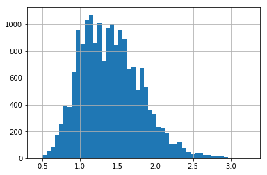

```python
avocado["AveragePrice"].hist(bins=50)
plt.show()
```

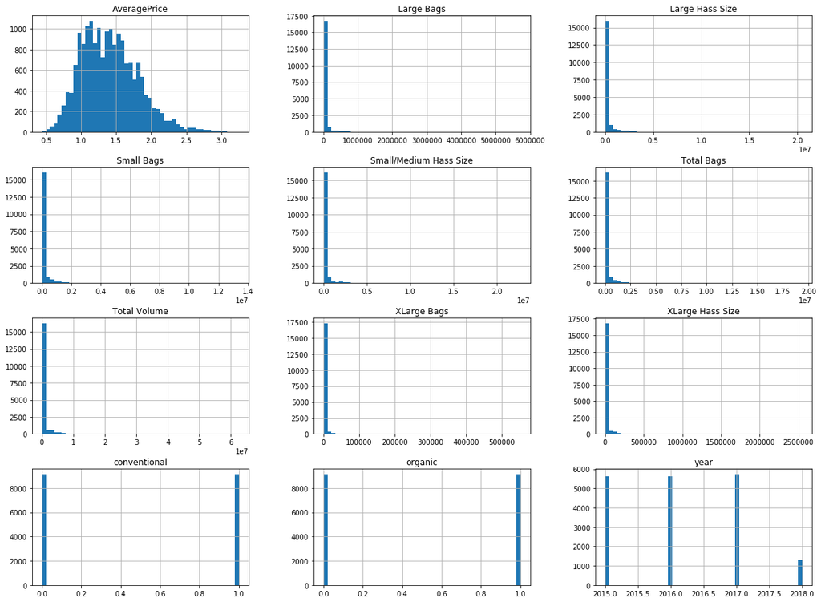

```python
avocado.hist(bins=50, figsize=(20,15))
plt.show()
```

```python
avocado = avocado.dropna(axis=0)
```

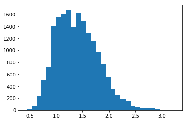

```python
plt.hist(avocado['AveragePrice'], bins = 30)
plt.show()
```

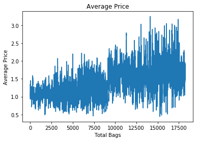

```python
plt.plot(avocado['AveragePrice'])
plt.title('Average Price')
plt.xlabel('Total Bags')
plt.ylabel('Average Price')
plt.show()
```

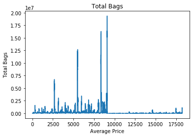

```python
plt.plot(avocado['Total Bags'])
plt.title('Total Bags')
plt.xlabel('Average Price')
plt.ylabel('Total Bags')
plt.show()
```

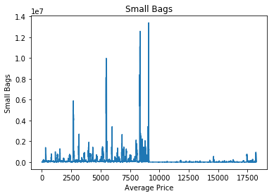

```python
plt.plot(avocado['Small Bags'])
plt.title('Small Bags')
plt.xlabel('Average Price')
plt.ylabel('Small Bags')
plt.show()
```

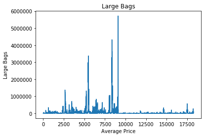

```python
plt.plot(avocado['Large Bags'])
plt.title('Large Bags')
plt.xlabel('Average Price')
plt.ylabel('Large Bags')
plt.show()
```

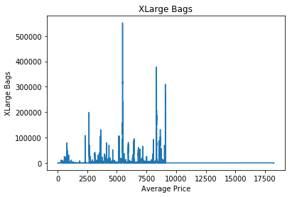

```python
plt.plot(avocado['XLarge Bags'])
plt.title('XLarge Bags')
plt.xlabel('Average Price')
plt.ylabel('XLarge Bags')
plt.show()
```

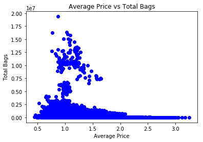

```python
plt.scatter(avocado['AveragePrice'],avocado['Total Bags'], color='blue')
plt.title('Average Price vs Total Bags')
plt.xlabel('Average Price')
plt.ylabel('Total Bags')
plt.show()
```

# Statistics

Here are the statistics of all the categories.

The most important ones are Average Price and Total Bags

The interesting thing about these statistics are the size of the bags and the mean.

You would think that the extra large bags would have more mean, but in actuality, the small bags have more mean.

```python
avocado.mean()
```

```
AveragePrice                   1.405978
Total Volume              850644.013009
Small/Medium Hass Size    293008.424531
Large Hass Size           295154.568356
XLarge Hass Size           22839.735993
Total Bags                239639.202060
Small Bags                182194.686696
Large Bags                 54338.088145
XLarge Bags                 3106.426507
year                        2016.147899
conventional                   0.500082
organic                        0.499918
dtype: float64
```

```python
x= avocado['AveragePrice'].mean()
x
```

```
1.4059784097758825
```

```python
x= avocado['Total Bags'].mean()
x
```

```
239639.20205983953
```

```python
avocado.min()
```

```
AveragePrice                 0.44
Total Volume                84.56
Small/Medium Hass Size       0.00
Large Hass Size              0.00
XLarge Hass Size             0.00
Total Bags                   0.00
Small Bags                   0.00
Large Bags                   0.00
XLarge Bags                  0.00
year                      2015.00
conventional                 0.00
organic                      0.00
dtype: float64
```

```python
avocado.max()
```

```
AveragePrice                     3.25
Total Volume              62505646.52
Small/Medium Hass Size    22743616.17
Large Hass Size           20470572.61
XLarge Hass Size           2546439.11
Total Bags                19373134.37
Small Bags                13384586.80
Large Bags                 5719096.61
XLarge Bags                 551693.65
year                          2018.00
conventional                     1.00
organic                          1.00
dtype: float64
```

```python
avocado.median()
```

```
AveragePrice                   1.37
Total Volume              107376.76
Small/Medium Hass Size      8645.30
Large Hass Size            29061.02
XLarge Hass Size             184.99
Total Bags                 39743.83
Small Bags                 26362.82
Large Bags                  2647.71
XLarge Bags                    0.00
year                        2016.00
conventional                   1.00
organic                        0.00
dtype: float64
```

```python
avocado.std()
```

```
AveragePrice              4.026766e-01
Total Volume              3.453545e+06
Small/Medium Hass Size    1.264989e+06
Large Hass Size           1.204120e+06
XLarge Hass Size          1.074641e+05
Total Bags                9.862424e+05
Small Bags                7.461785e+05
Large Bags                2.439660e+05
XLarge Bags               1.769289e+04
year                      9.399385e-01
conventional              5.000137e-01
organic                   5.000137e-01
dtype: float64
```

# Correlation

Not all the features are correlated with the Average Price column.

Instead most of them are correlated with each other.

```python
corr_matrix = avocado.corr()
corr_matrix
```

|  | AveragePrice | Total Volume | Small/Medium Hass Size | Large Hass Size | XLarge Hass Size | Total Bags | Small Bags | Large Bags | XLarge Bags | year | conventional | organic |
| --- | --- | --- | --- | --- | --- | --- | --- | --- | --- | --- | --- | --- |
| AveragePrice | 1.000000 | -0.192752 | -0.208317 | -0.172928 | -0.179446 | -0.177088 | -0.174730 | -0.172940 | -0.117592 | 0.093197 | -0.615845 | 0.615845 |
| Total Volume | -0.192752 | 1.000000 | 0.977863 | 0.974181 | 0.872202 | 0.963047 | 0.967238 | 0.880640 | 0.747157 | 0.017193 | 0.232434 | -0.232434 |
| Small/Medium Hass Size | -0.208317 | 0.977863 | 1.000000 | 0.926110 | 0.833389 | 0.920057 | 0.925280 | 0.838645 | 0.699377 | 0.003353 | 0.225819 | -0.225819 |
| Large Hass Size | -0.172928 | 0.974181 | 0.926110 | 1.000000 | 0.887855 | 0.905787 | 0.916031 | 0.810015 | 0.688809 | -0.009559 | 0.232289 | -0.232289 |
| XLarge Hass Size | -0.179446 | 0.872202 | 0.833389 | 0.887855 | 1.000000 | 0.792314 | 0.802733 | 0.698471 | 0.679861 | -0.036531 | 0.210027 | -0.210027 |
| Total Bags | -0.177088 | 0.963047 | 0.920057 | 0.905787 | 0.792314 | 1.000000 | 0.994335 | 0.943009 | 0.804233 | 0.071552 | 0.217788 | -0.217788 |
| Small Bags | -0.174730 | 0.967238 | 0.925280 | 0.916031 | 0.802733 | 0.994335 | 1.000000 | 0.902589 | 0.806845 | 0.063915 | 0.220535 | -0.220535 |
| Large Bags | -0.172940 | 0.880640 | 0.838645 | 0.810015 | 0.698471 | 0.943009 | 0.902589 | 1.000000 | 0.710858 | 0.087891 | 0.193177 | -0.193177 |
| XLarge Bags | -0.117592 | 0.747157 | 0.699377 | 0.688809 | 0.679861 | 0.804233 | 0.806845 | 0.710858 | 1.000000 | 0.081033 | 0.175483 | -0.175483 |
| year | 0.093197 | 0.017193 | 0.003353 | -0.009559 | -0.036531 | 0.071552 | 0.063915 | 0.087891 | 0.081033 | 1.000000 | 0.000032 | -0.000032 |
| conventional | -0.615845 | 0.232434 | 0.225819 | 0.232289 | 0.210027 | 0.217788 | 0.220535 | 0.193177 | 0.175483 | 0.000032 | 1.000000 | -1.000000 |
| organic | 0.615845 | -0.232434 | -0.225819 | -0.232289 | -0.210027 | -0.217788 | -0.220535 | -0.193177 | -0.175483 | -0.000032 | -1.000000 | 1.000000 |

```python
corr_matrix["AveragePrice"].sort_values(ascending=False)
```

```
AveragePrice              1.000000
organic                   0.615845
year                      0.093197
XLarge Bags              -0.117592
Large Hass Size          -0.172928
Large Bags               -0.172940
Small Bags               -0.174730
Total Bags               -0.177088
XLarge Hass Size         -0.179446
Total Volume             -0.192752
Small/Medium Hass Size   -0.208317
conventional             -0.615845
Name: AveragePrice, dtype: float64
```

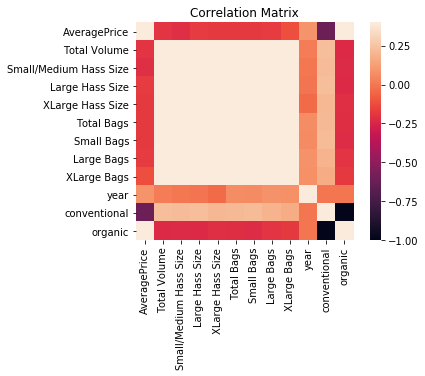

```python
sns.heatmap(avocado.corr(), vmax = 0.4, square = True)
plt.title("Correlation Matrix")
fig = plt.figure(figsize = (16, 8))
plt.show()
```

# Scatter Plots

These are scatter plots base on the Average Price and Total Bags of Avocados and their bag sizes.

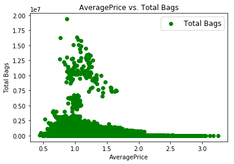

```python
plt.scatter(avocado['AveragePrice'],avocado['Total Bags'], color='green' )
plt.title('AveragePrice vs. Total Bags')
plt.xlabel('AveragePrice')
plt.ylabel('Total Bags')
plt.legend(loc="upper right", fontsize=12)
plt.show()
```

# The smaller bags are the higher number of bags that are taken

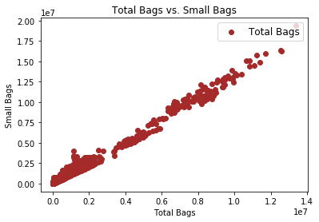

```python
plt.scatter(avocado['Small Bags'],avocado['Total Bags'], color='brown' )
plt.title('Total Bags vs. Small Bags')
plt.xlabel('Total Bags')
plt.ylabel('Small Bags')
plt.legend(loc="upper right", fontsize=12)
plt.show()
```

# than the other size bags, Large

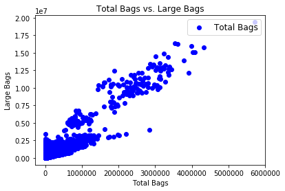

```python
plt.scatter(avocado['Large Bags'],avocado['Total Bags'], color='blue' )
plt.title('Total Bags vs. Large Bags')
plt.xlabel('Total Bags')
plt.ylabel('Large Bags')
plt.legend(loc="upper right", fontsize=12)
plt.show()
```

# and XLarge

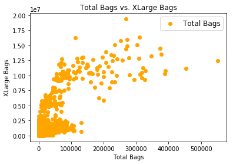

```python
plt.scatter(avocado['XLarge Bags'],avocado['Total Bags'], color='orange' )
plt.title('Total Bags vs. XLarge Bags')
plt.xlabel('Total Bags')
plt.ylabel('XLarge Bags')
plt.legend(loc="upper right", fontsize=12)
plt.show()
```

# Scatter Matrix Plot

```
array([[<matplotlib.axes._subplots.AxesSubplot object at 0x1a1bb62358>,
      dtype=object)
```

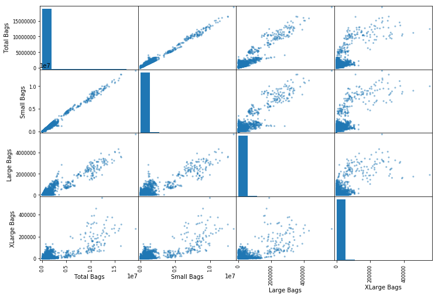

```python
from pandas.plotting import scatter_matrix

attributes = ["Total Bags", "Small Bags", "Large Bags",
              "XLarge Bags"]
scatter_matrix(avocado[attributes], figsize=(12, 8))
```

# Split Test

Thsi is the training of the Regression model.

I first split up the data into an X array that contains the features to train on, and a y array with the target variable.

```python
from sklearn.model_selection import train_test_split
train_set, test_set = train_test_split(avocado, test_size=0.2, random_state=42)
test_set.head()
```

|  | AveragePrice | Total Volume | Small/Medium Hass Size | Large Hass Size | XLarge Hass Size | Total Bags | Small Bags | Large Bags | XLarge Bags | year | conventional | organic |
| --- | --- | --- | --- | --- | --- | --- | --- | --- | --- | --- | --- | --- |
| 8604 | 0.82 | 218329.70 | 79239.58 | 26356.05 | 2998.74 | 109735.33 | 73393.34 | 34338.97 | 2003.02 | 2018 | 1.0 | 0.0 |
| 2608 | 0.97 | 391514.43 | 228324.13 | 72749.38 | 100.62 | 90340.30 | 44449.47 | 45890.83 | 0.00 | 2015 | 1.0 | 0.0 |
| 14581 | 1.44 | 3907.40 | 1147.09 | 39.51 | 0.00 | 2720.80 | 2717.47 | 3.33 | 0.00 | 2016 | 0.0 | 1.0 |
| 4254 | 0.97 | 267953.78 | 150786.30 | 27025.48 | 565.65 | 89576.35 | 74664.71 | 14911.64 | 0.00 | 2016 | 1.0 | 0.0 |
| 16588 | 1.45 | 8805.28 | 828.39 | 3.24 | 0.00 | 7973.65 | 7456.43 | 517.22 | 0.00 | 2017 | 0.0 | 1.0 |

```python
Y_train = train_set['AveragePrice']
X_train = train_set.drop(['AveragePrice'],axis = 1)
```

```python
Y_test = test_set['AveragePrice']
X_test = test_set.drop(['AveragePrice'],axis = 1)
```

Going to be using Linear Regression because the target variable, Average Price is continuous.

# Linear Regression

Creating and Training the Model

```python
from sklearn.linear_model import LinearRegression
from sklearn.metrics import mean_squared_error
LR = LinearRegression()
LR.fit(X_train, Y_train)
```

```
LinearRegression(copy_X=True, fit_intercept=True, n_jobs=None,
         normalize=False)
```

```python
pred = LR.predict(X_test)
mean_squared_error(pred, Y_test)
```

```
0.09760990350817661
```

# Random Forest

```python
from sklearn.ensemble import RandomForestRegressor
RFR = RandomForestRegressor (n_estimators = 100, min_samples_leaf = 10, random_state = 42)
RFR.fit(X_train, Y_train)
```

```
RandomForestRegressor(bootstrap=True, criterion='mse', max_depth=None,
           max_features='auto', max_leaf_nodes=None,
           min_impurity_decrease=0.0, min_impurity_split=None,
           min_samples_leaf=10, min_samples_split=2,
           min_weight_fraction_leaf=0.0, n_estimators=100, n_jobs=None,
           oob_score=False, random_state=42, verbose=0, warm_start=False)
```

```python
pred2 = RFR.predict(X_test)
mean_squared_error(pred2, Y_test)
```

```
0.037579361799355254
```

This, Random Forest Regression is much better than Linear Regression... the smaller the number, the better the result!

RMSE is lower than the previous model, so the RandomForest Regressor is the best model.

# Support Vector Regression

This is the Support Vector Regression

```python
from sklearn.svm import LinearSVR

svm_reg = LinearSVR(epsilon=1.5, random_state=42)
svm_reg.fit(X_train, Y_train)
```

```
LinearSVR(C=1.0, dual=True, epsilon=1.5, fit_intercept=True,
     intercept_scaling=1.0, loss='epsilon_insensitive', max_iter=1000,
     random_state=42, tol=0.0001, verbose=0)
```

```python
pred2 = svm_reg.predict(X_test)
mean_squared_error(pred2, Y_test)
```

```
8.61864082852389
```

This prediction is much higher

With all 3 Regression tests, the best result is the Random Forest Regression!

Conclusion With the statistics drawn from the analysis, I found out which price is highly positively and negatively coorelated with. Not all the features are correlated with the Average Price column. Instead, most of them are correlated with each other.